# Graph redundancy stats

Jennie Lavine

8/26/2021

```r
require(tidyverse)
```

```r
graph_stats = read_tsv("graph_stats.txt", col_names=F)
#graph_stats_old = read_tsv("graph_stats_old.txt", col_names=F)
colnames(graph_stats) = c("n_receptors", "n_effectors",
        "bot_degeneracy", "bot_dens_net",
        "bot_mean_deg", "bot_sd_deg",
        "bot_n_modules", "bot_modularity_net",
        "bot_mean_path_length", "bot_sd_path_length",
        "bip_degeneracy", "bip_dens_net", "bip_mean_deg", "bip_sd_deg",
        "bip_n_modules", "bip_modularity_net", "bot_skew_deg", "bip_skew_deg")

redundancy_stats = read_tsv("redundancy_stats.txt", col_names=F)
colnames(redundancy_stats) = paste("orphans_", 0:(ncol(redundancy_stats)-1), sep='')

graph_stats$orphans_3 = redundancy_stats$orphans_3
graph_stats$orphans_4 = redundancy_stats$orphans_4

graph_stats$n_connections = graph_stats$bip_dens_net * 8 * 16
graph_stats$ID = 1:1000

ind = which.max(table(graph_stats$n_connections))
graph_stats_28 <- subset(graph_stats,
                    graph_stats$n_connections==as.numeric(names(ind)))
```

Test for association between orphans 4 and other variable

```r
linmod <- lm(data = graph_stats_28, formula = log(orphans_4) ~ bot_mean_path_length + bip_modularity_net + bip_n_modules + bot_dens_net + bot_modularity_net + bot_n_modules + bip_dens_net + bot_sd_deg + bip_sd_deg + bot_skew_deg + bip_skew_deg + bip_mean_deg + bot_mean_deg)

bestmod = step(linmod)
```

```
## Start:  AIC=-277.55
## log(orphans_4) ~ bot_mean_path_length + bip_modularity_net +
##     bip_n_modules + bot_dens_net + bot_modularity_net + bot_n_modules +
##     bip_dens_net + bot_sd_deg + bip_sd_deg + bot_skew_deg + bip_skew_deg +
##     bip_mean_deg + bot_mean_deg
##
##
## Step:  AIC=-277.55
## log(orphans_4) ~ bot_mean_path_length + bip_modularity_net +
##     bip_n_modules + bot_dens_net + bot_modularity_net + bot_n_modules +
##     bip_dens_net + bot_sd_deg + bip_sd_deg + bot_skew_deg + bip_skew_deg +
##     bip_mean_deg
##
##
## Step:  AIC=-277.55
## log(orphans_4) ~ bot_mean_path_length + bip_modularity_net +
##     bip_n_modules + bot_dens_net + bot_modularity_net + bot_n_modules +
##     bip_dens_net + bot_sd_deg + bip_sd_deg + bot_skew_deg + bip_skew_deg
##
##
## Step:  AIC=-277.55
## log(orphans_4) ~ bot_mean_path_length + bip_modularity_net +
##     bip_n_modules + bot_dens_net + bot_modularity_net + bot_n_modules +
##     bot_sd_deg + bip_sd_deg + bot_skew_deg + bip_skew_deg
##
##                        Df Sum of Sq    RSS     AIC
## - bip_n_modules         1    0.0024 17.227 -279.53
## - bot_modularity_net    1    0.0047 17.230 -279.51
## - bip_modularity_net    1    0.0667 17.292 -279.00
## <none>                              17.225 -277.55
## - bot_mean_path_length  1    0.6101 17.835 -274.60
## - bot_n_modules         1    0.6314 17.856 -274.43
## - bot_skew_deg          1    0.7907 18.015 -273.17
## - bot_sd_deg            1    1.9071 19.132 -264.63
## - bot_dens_net          1    4.7270 21.952 -245.11
## - bip_skew_deg          1   17.2981 34.523 -180.82
## - bip_sd_deg            1   22.8027 40.027 -159.81
##
## Step:  AIC=-279.53
## log(orphans_4) ~ bot_mean_path_length + bip_modularity_net +
```

[output cut: 29 more lines]

```
## - bip_sd_deg            1   23.6734 40.904 -160.73
##
## Step:  AIC=-282.97
## log(orphans_4) ~ bot_mean_path_length + bot_dens_net + bot_n_modules +
##     bot_sd_deg + bip_sd_deg + bot_skew_deg + bip_skew_deg
##
##                        Df Sum of Sq    RSS     AIC
## <none>                              17.295 -282.97
## - bot_mean_path_length  1    0.7612 18.056 -278.86
## - bot_skew_deg          1    0.8690 18.164 -278.01
## - bot_n_modules         1    1.0101 18.305 -276.91
## - bot_sd_deg            1    2.2811 19.576 -267.38
## - bot_dens_net          1    5.3649 22.659 -246.61
## - bip_skew_deg          1   19.2820 36.577 -178.61
## - bip_sd_deg            1   23.8539 41.148 -161.89
```

```r
bestmod
```

```
##
## Call:
## lm(formula = log(orphans_4) ~ bot_mean_path_length + bot_dens_net +
##     bot_n_modules + bot_sd_deg + bip_sd_deg + bot_skew_deg +
##     bip_skew_deg, data = graph_stats_28)
##
## Coefficients:
##          (Intercept)  bot_mean_path_length          bot_dens_net
##               0.6438                0.3922              -13.8348
##        bot_n_modules            bot_sd_deg            bip_sd_deg
##              -0.1099                0.2685                6.1987
##         bot_skew_deg          bip_skew_deg
##               0.2023               -2.6733
```

```r
var_cov_bestmod = vcov(bestmod)
round(cov2cor(var_cov_bestmod), 3)
```

```
##                      (Intercept) bot_mean_path_length bot_dens_net
## (Intercept)                1.000               -0.642       -0.599
## bot_mean_path_length      -0.642                1.000        0.114
## bot_dens_net              -0.599                0.114        1.000
## bot_n_modules             -0.280                0.149        0.038
## bot_sd_deg                -0.298                0.540        0.035
## bip_sd_deg                -0.187                0.042       -0.437
## bot_skew_deg               0.156               -0.302        0.246
## bip_skew_deg               0.187               -0.153       -0.370
##                      bot_n_modules bot_sd_deg bip_sd_deg bot_skew_deg
## (Intercept)                 -0.280     -0.298     -0.187        0.156
## bot_mean_path_length         0.149      0.540      0.042       -0.302
## bot_dens_net                 0.038      0.035     -0.437        0.246
## bot_n_modules                1.000      0.135      0.031       -0.140
## bot_sd_deg                   0.135      1.000     -0.389       -0.229
## bip_sd_deg                   0.031     -0.389      1.000       -0.344
## bot_skew_deg                -0.140     -0.229     -0.344        1.000
## bip_skew_deg                 0.024      0.050     -0.007        0.130
##                      bip_skew_deg
## (Intercept)                 0.187
## bot_mean_path_length       -0.153
## bot_dens_net               -0.370
## bot_n_modules               0.024
## bot_sd_deg                  0.050
## bip_sd_deg                 -0.007
## bot_skew_deg                0.130
## bip_skew_deg                1.000
```

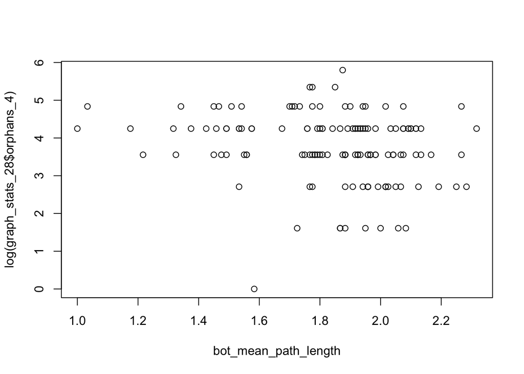

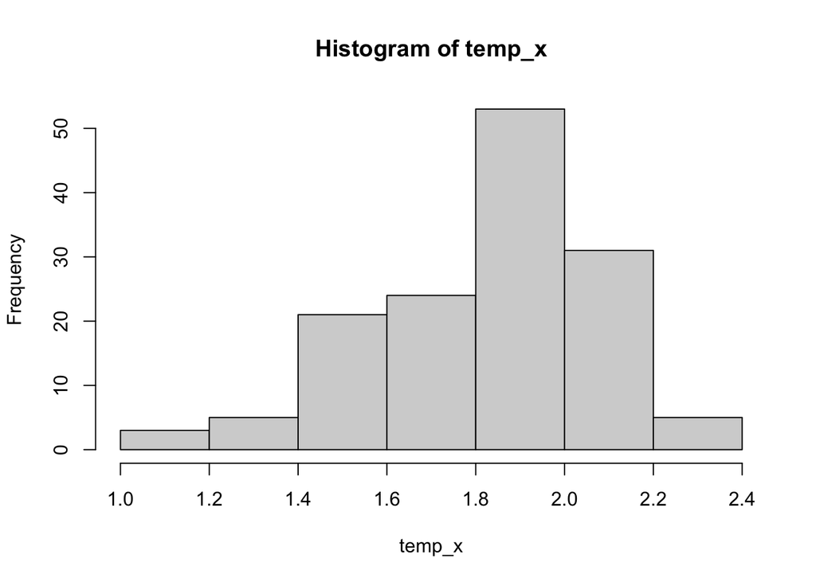

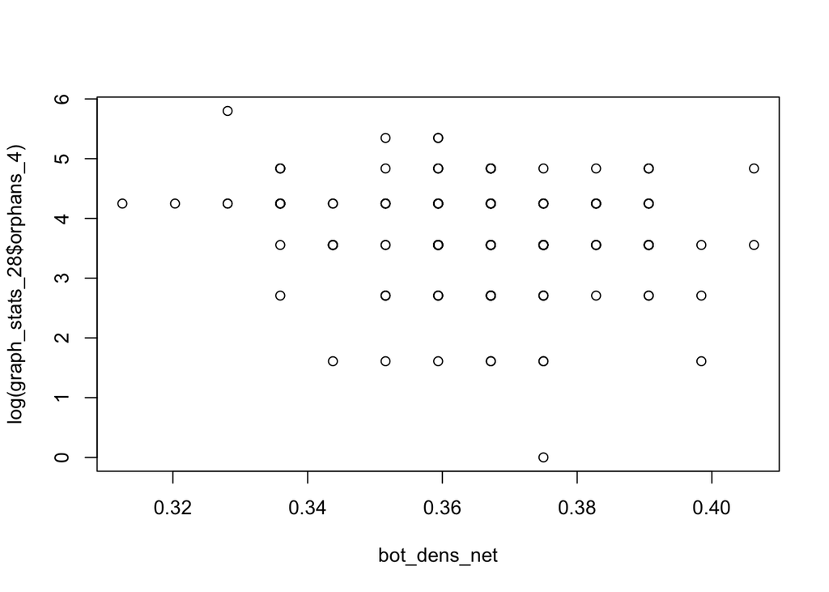

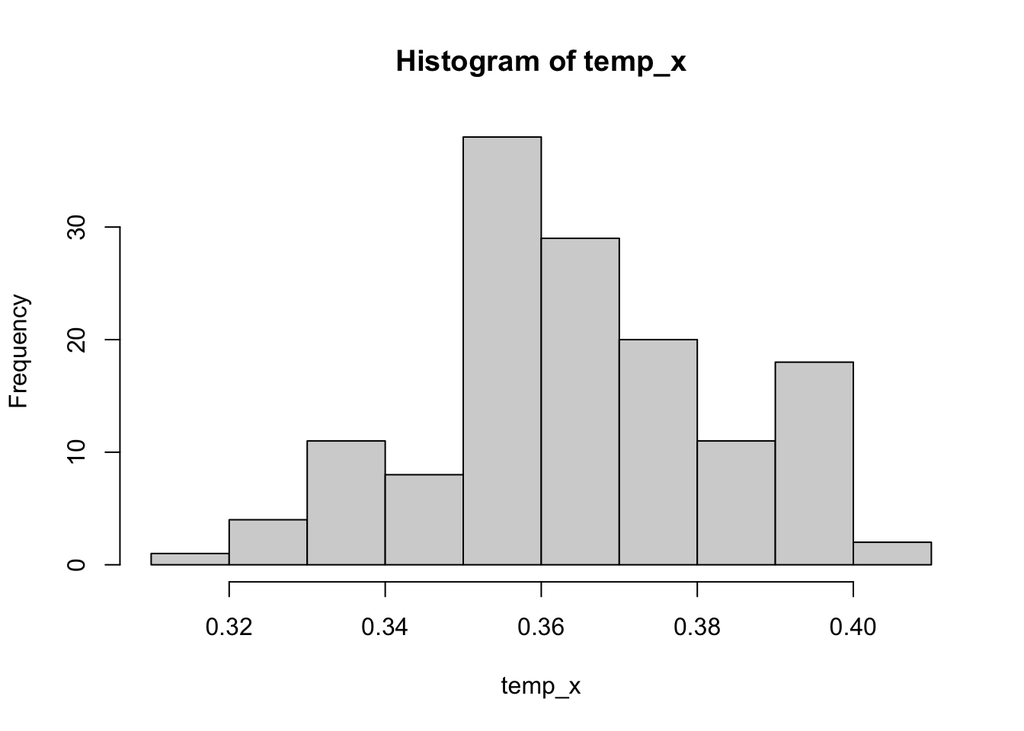

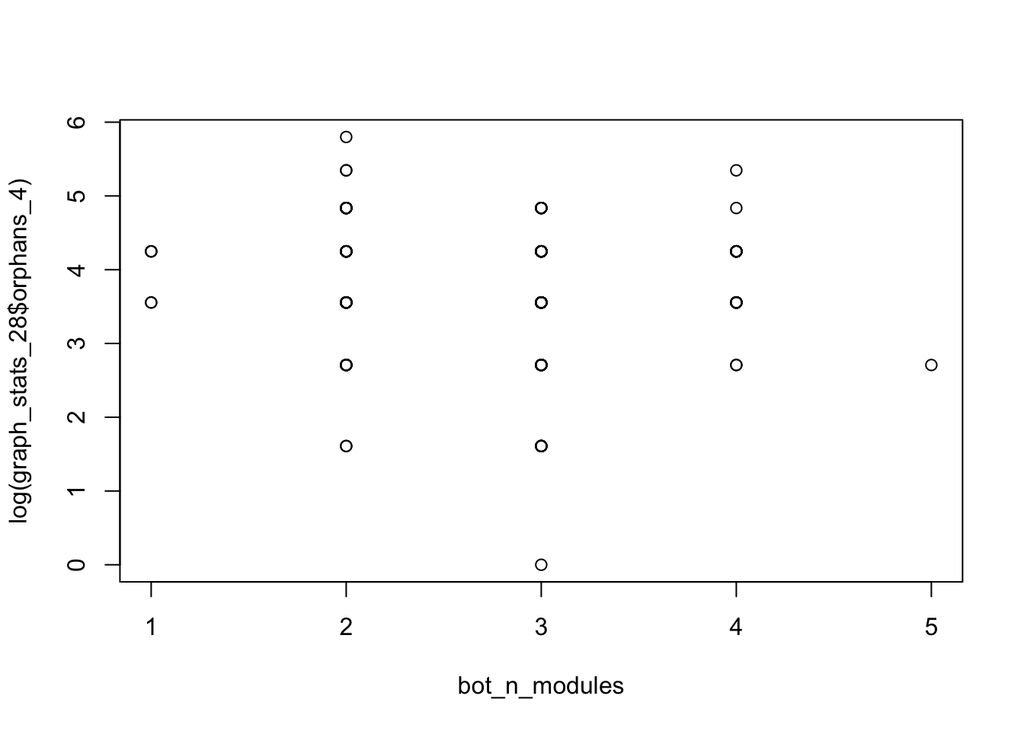

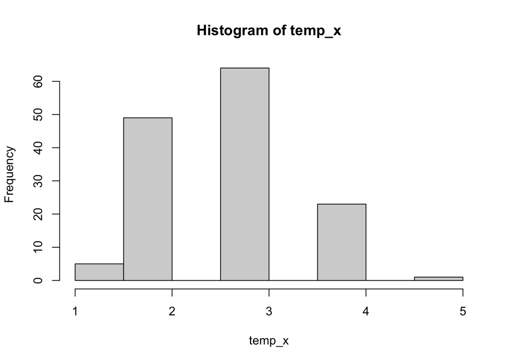

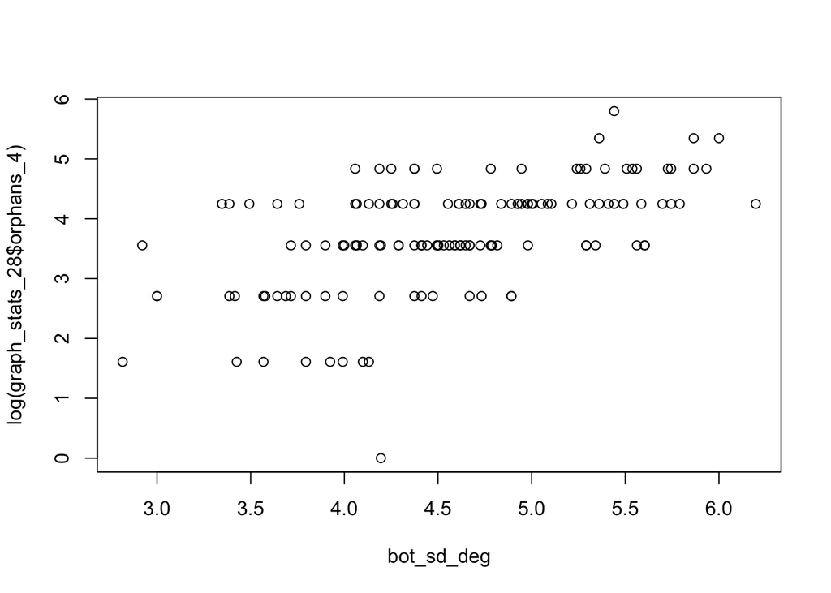

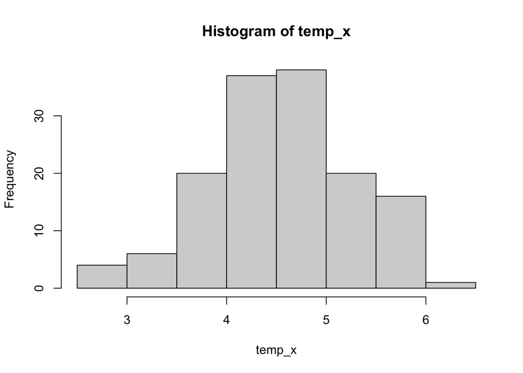

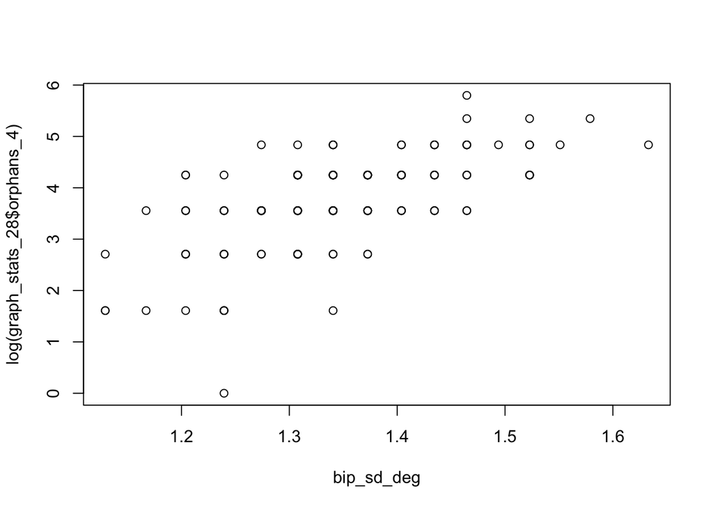

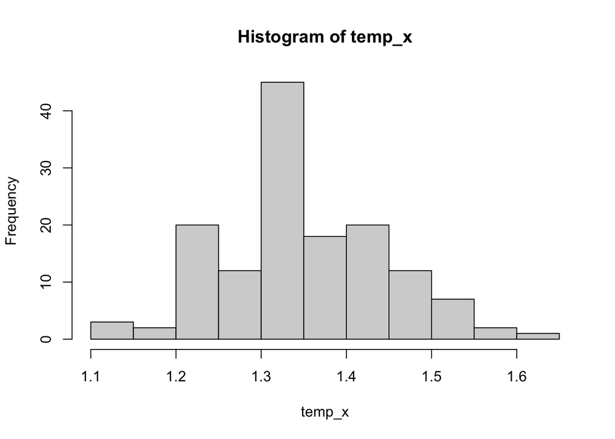

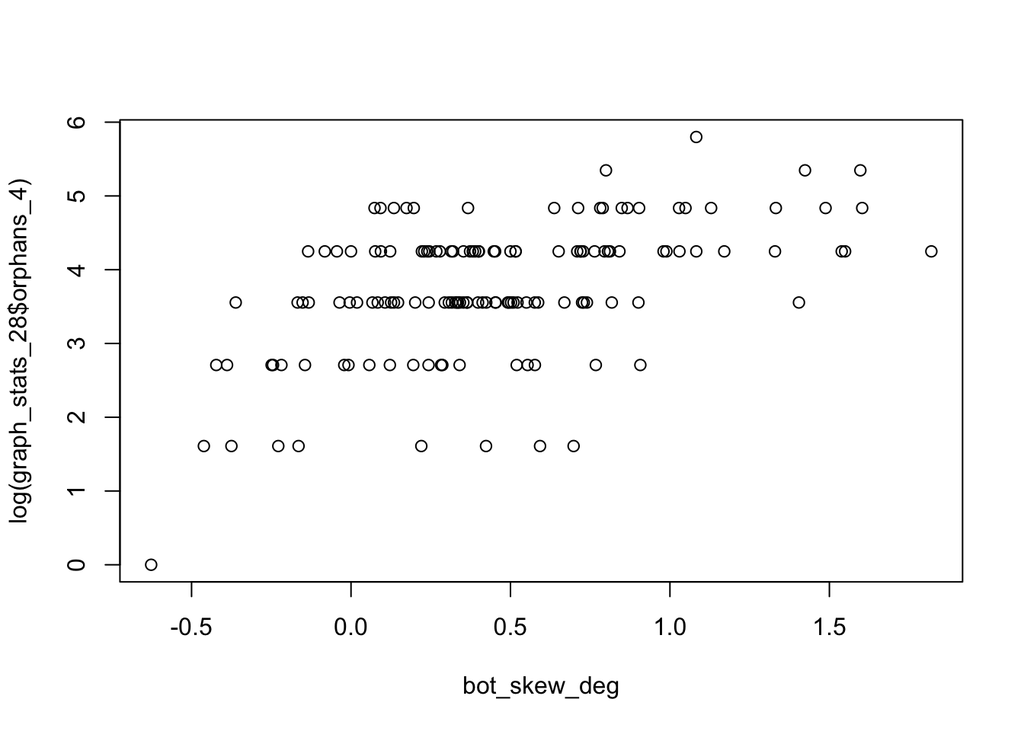

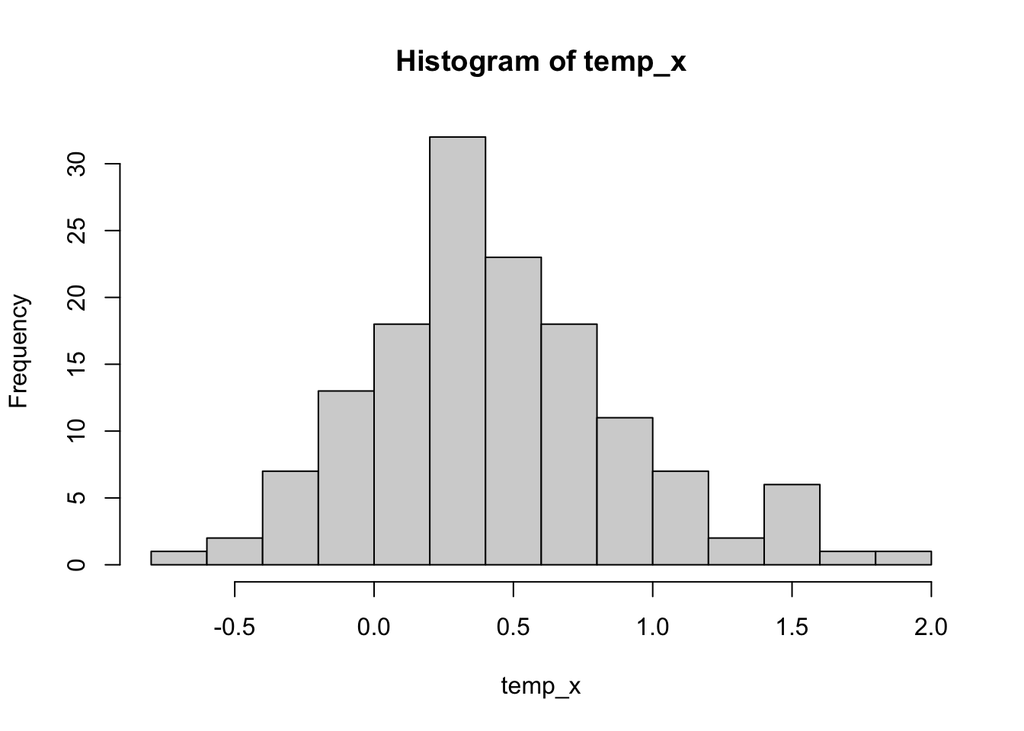

[2 more figures not shown]

```r
coef_names <- tail(names(bestmod$coefficients), -1)
for (coef in coef_names){
    temp_x = unlist(graph_stats_28[,coef])
  plot(temp_x, log(graph_stats_28$orphans_4)
       , xlab=coef)
  hist(temp_x)
}
```

```r
linmod <- lm(data = graph_stats_28, formula = log(orphans_4) ~  bot_sd_deg + bip_sd_deg + bot_skew_deg + bip_skew_deg + bot_modularity_net)

bestmod = step(linmod)
```

```
## Start:  AIC=-233.74
## log(orphans_4) ~ bot_sd_deg + bip_sd_deg + bot_skew_deg + bip_skew_deg +
##     bot_modularity_net
##
##                      Df Sum of Sq    RSS     AIC
## - bot_modularity_net  1    0.0105 25.171 -235.68
## <none>                            25.161 -233.74
## - bot_sd_deg          1    1.0317 26.192 -230.03
## - bot_skew_deg        1    3.5908 28.751 -216.79
## - bip_sd_deg          1   18.1117 43.272 -158.74
## - bip_skew_deg        1   29.5455 54.706 -125.45
##
## Step:  AIC=-235.68
## log(orphans_4) ~ bot_sd_deg + bip_sd_deg + bot_skew_deg + bip_skew_deg
##
##                Df Sum of Sq    RSS     AIC
## <none>                      25.171 -235.68
## - bot_sd_deg    1    1.5228 26.694 -229.34
## - bot_skew_deg  1    3.8366 29.008 -217.53
## - bip_sd_deg    1   18.1065 43.278 -160.72
## - bip_skew_deg  1   30.1978 55.369 -125.74
```

```r
bestmod
```

```
##
## Call:
## lm(formula = log(orphans_4) ~ bot_sd_deg + bip_sd_deg + bot_skew_deg +
##     bip_skew_deg, data = graph_stats_28)
##
## Coefficients:
##  (Intercept)    bot_sd_deg    bip_sd_deg  bot_skew_deg  bip_skew_deg
##      -1.5497        0.1842        4.8293        0.3846       -3.0800
```

How strongly related are these predictors with each other?

```r
var_cov_bestmod = vcov(bestmod)
cov2cor(var_cov_bestmod)
```

```
##              (Intercept)  bot_sd_deg bip_sd_deg bot_skew_deg bip_skew_deg
## (Intercept)    1.0000000  0.10018243 -0.8267845   0.19727743   -0.1851060
## bot_sd_deg     0.1001824  1.00000000 -0.5666336  -0.06899204    0.1553576
## bip_sd_deg    -0.8267845 -0.56663358  1.0000000  -0.24975989   -0.1948870
## bot_skew_deg   0.1972774 -0.06899204 -0.2497599   1.00000000    0.2270189
## bip_skew_deg  -0.1851060  0.15535762 -0.1948870   0.22701894    1.0000000
```

```r
cor.test(graph_stats_28$bot_skew_deg, graph_stats_28$bot_sd_deg)
```

```
##
##  Pearson's product-moment correlation
##
## data:  graph_stats_28$bot_skew_deg and graph_stats_28$bot_sd_deg
## t = 3.4469, df = 140, p-value = 0.0007491
## alternative hypothesis: true correlation is not equal to 0
## 95 percent confidence interval:
##  0.1205146 0.4248431
## sample estimates:
##       cor
## 0.2796894
```

```r
cor.test(graph_stats_28$bot_skew_deg, graph_stats_28$bip_skew_deg)
```

```
##
##  Pearson's product-moment correlation
##
## data:  graph_stats_28$bot_skew_deg and graph_stats_28$bip_skew_deg
## t = -2.5441, df = 140, p-value = 0.01204
## alternative hypothesis: true correlation is not equal to 0
## 95 percent confidence interval:
##  -0.36239089 -0.04711666
## sample estimates:
##        cor
## -0.2102124
```

```r
cor.test(graph_stats_28$bot_sd_deg, graph_stats_28$bip_sd_deg)
```

```
##
##  Pearson's product-moment correlation
##
## data:  graph_stats_28$bot_sd_deg and graph_stats_28$bip_sd_deg
## t = 8.7415, df = 140, p-value = 6.424e-15
## alternative hypothesis: true correlation is not equal to 0
## 95 percent confidence interval:
##  0.4760869 0.6912763
## sample estimates:
##       cor
## 0.5942133
```

```r
cor.test(graph_stats_28$bip_skew_deg, graph_stats_28$bip_sd_deg)
```

```
##
##  Pearson's product-moment correlation
##
## data:  graph_stats_28$bip_skew_deg and graph_stats_28$bip_sd_deg
## t = 0.60647, df = 140, p-value = 0.5452
## alternative hypothesis: true correlation is not equal to 0
## 95 percent confidence interval:
##  -0.1145041  0.2141106
## sample estimates:
##        cor
## 0.05118872
```

Now let’s pull out graphs that had especially high and low redundancy and see where they fall in the above, then we will go back to Julia and visualize them.

```r
ids_ordered = graph_stats_28$ID[order(graph_stats_28$orphans_4)]
high_redun_ids = head(ids_ordered, 20)
low_redun_ids = tail(ids_ordered, 20)
```

If we include all the results (i.e., regardless of # of connections), what do we find?

```r
linmod <- lm(data = graph_stats, formula = log(orphans_4+0.1) ~ bip_dens_net + bot_sd_deg + bip_sd_deg + bot_skew_deg + bip_skew_deg)

bestmod = step(linmod, trace=0)
bestmod
```

```
##
## Call:
## lm(formula = log(orphans_4 + 0.1) ~ bip_dens_net + bot_sd_deg +
##     bip_sd_deg + bot_skew_deg + bip_skew_deg, data = graph_stats)
##
## Coefficients:
##  (Intercept)  bip_dens_net    bot_sd_deg    bip_sd_deg  bot_skew_deg
##     20.90719    -105.70773       0.20946       5.76569       0.08436
## bip_skew_deg
##     -3.69723
```

```r
var_cov_bestmod = vcov(bestmod)
round(cov2cor(var_cov_bestmod), 3)
```

```
##              (Intercept) bip_dens_net bot_sd_deg bip_sd_deg bot_skew_deg
## (Intercept)        1.000       -0.794      0.032     -0.105       -0.227
## bip_dens_net      -0.794        1.000      0.004     -0.434        0.331
## bot_sd_deg         0.032        0.004      1.000     -0.538       -0.041
## bip_sd_deg        -0.105       -0.434     -0.538      1.000       -0.216
## bot_skew_deg      -0.227        0.331     -0.041     -0.216        1.000
## bip_skew_deg      -0.858        0.832      0.109     -0.231        0.259
##              bip_skew_deg
## (Intercept)        -0.858
## bip_dens_net        0.832
## bot_sd_deg          0.109
## bip_sd_deg         -0.231
## bot_skew_deg        0.259
## bip_skew_deg        1.000
```

Conclusions thus far: The shape of the degree distribution is the strongest predictor of redundancy as measured by the frequency of networks with three or four orphan effector after removing all combinations of four edges.

The skewness of the bipartite graph is a stronger predictor (AIC values from various ’step’s) than the skewness of the bottom projection. They go in opposite directions – a high positive skewness (i.e., long right tail) of the bipartite graph is associated with higher redundancy (i.e., fewer 4-orphans); in contrast, a lower skewness (closer to 0, in this case, also includes negative numbers, maybe should try with magnitude instead?) of the bottom projection is associated with higher redundancy. Smaller variances in both are associated with higher redundancy, though for the more skewed distributions, the metric of variance may not be very useful. This is in line with the notion of a power-law degree distribution in the bipartite network leading to a more robust system.

I now include plots of a few of the particularly high and low redundancy graphs and some associated metrics.

## High redundancy graphs

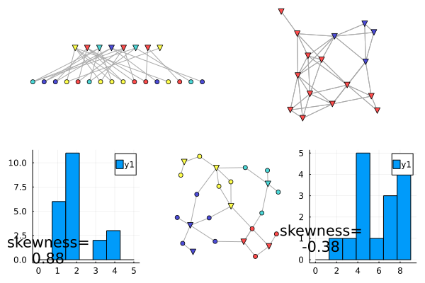

High redundancy

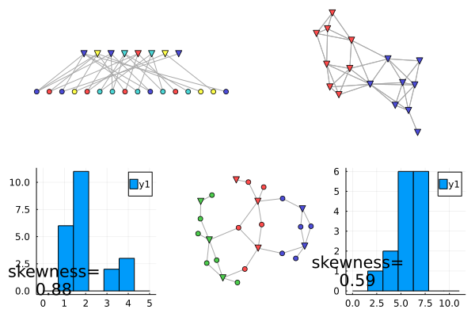

High redundancy

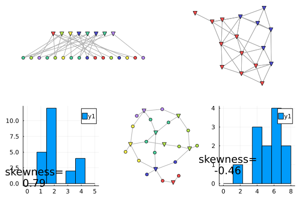

High redundancy

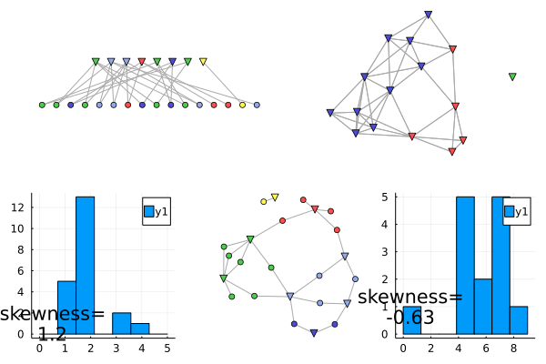

High redundancy

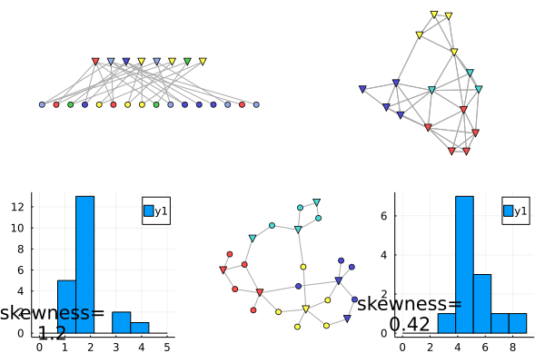

High redundancy

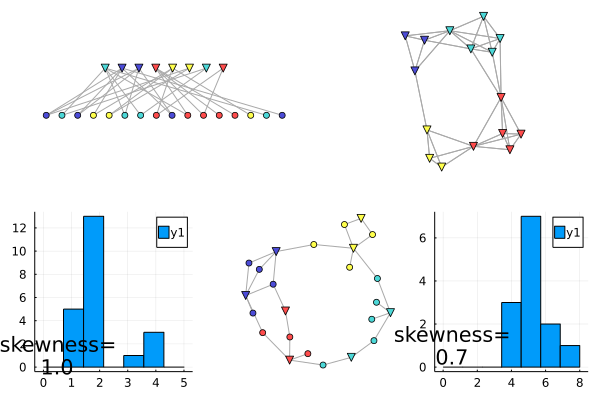

High redundancy

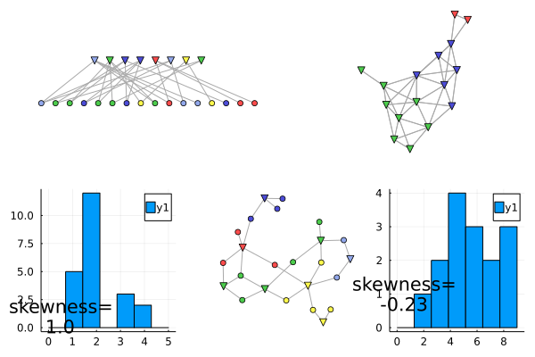

High redundancy

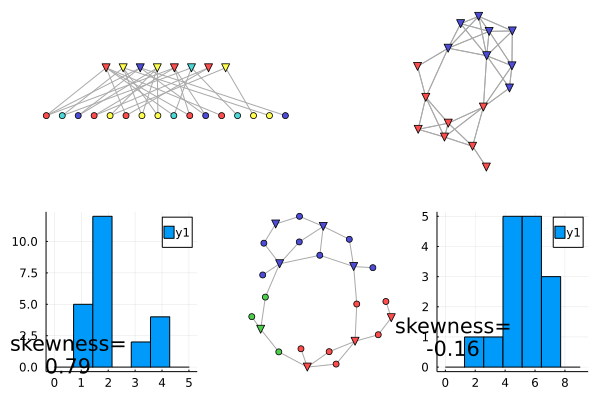

High redundancy

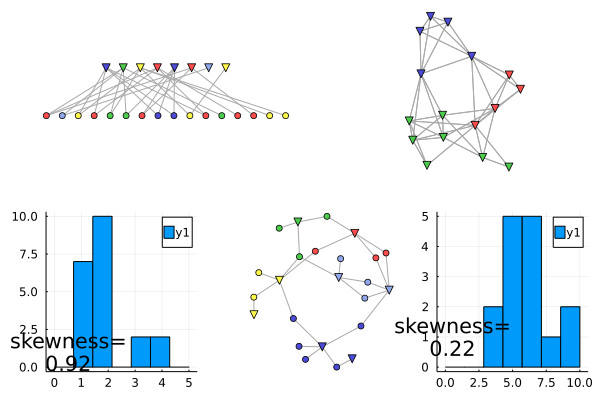

High redundancy

## Low redundancy graphs

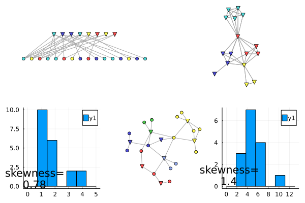

Low redundancy

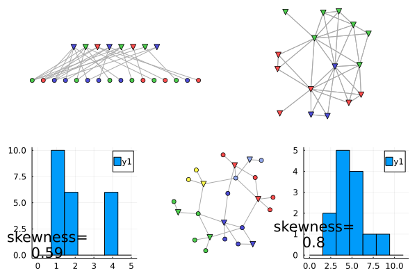

Low redundancy

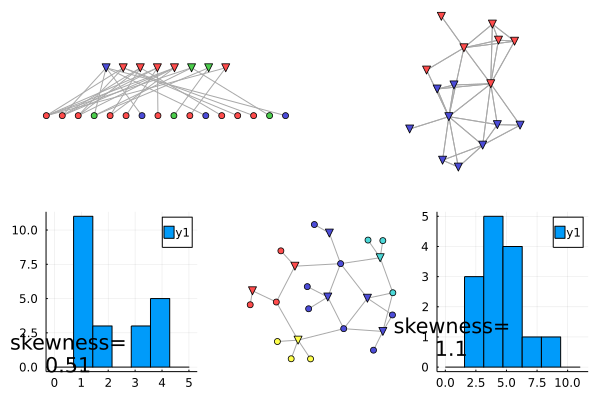

Low redundancy

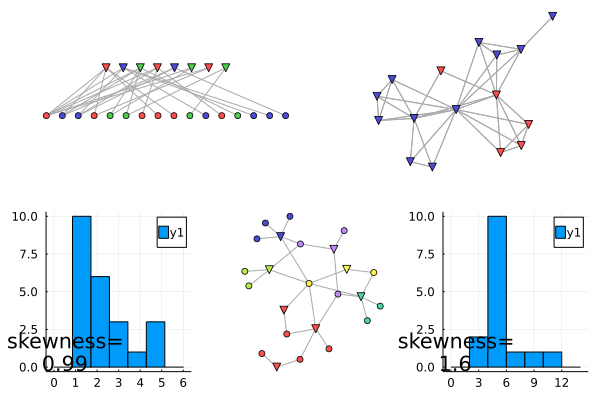

Low redundancy